# Introduction to SC19062

### Question 2

Repeat Project 7.A for the sample skewness statistic. Compare the coverage rates for normal populations (skewness 0) and $\chi^2(5)$ distributions (positive skewness).

### Answer 2

```r
# for normal populations
library(boot)
set.seed(1234)
# define a function to compute skewness using function "boot"
sk<-function(x,i) mean((x[i]-mean(x[i]))^3)/mean((x[i]-mean(x[i]))^2)^1.5
n<-500     # number of replicates in Monte Carlo
m<-200     # sample size
norm_cil<-norm_cir<-basic_cil<-basic_cir<-perc_cil<-perc_cir<-numeric(n)
# Monte Carlo and bootstrap
for (i in 1:n) {
  x<-rnorm(m)
  boot.obj<-boot(x,statistic=sk,R=2000)
  ci<-boot.ci(boot.obj,type=c('norm','basic','perc'))
  norm_cil[i]<-ci$normal[2]
  norm_cir[i]<-ci$normal[3]
  basic_cil[i]<-ci$basic[4]
  basic_cir[i]<-ci$basic[5]
  perc_cil[i]<-ci$percent[4]
  perc_cir[i]<-ci$percent[5]
}
# compute coverage rates
print(c(mean((norm_cil<0)*(norm_cir>0)),mean((basic_cil<0)*(basic_cir>0)),
        mean((perc_cil<0)*(perc_cir>0))))
```

```
## [1] 0.922 0.922 0.938
```

We can see that the coverage rates for normal populations under the standard normal confidence interval, the basic bootstrap confidence interval, and the percentile confidence interval are about 0.922, 0.922 and 0.938 respectively. For normal populations, percentile confidence interval performs a little better.

As for $\chi^2(5)$ distributions, we can get that the skewness of this distribution is $\sqrt{8/5}$ by integration.

```r
# for chi-square(5) dsitributions
library(boot)
set.seed(1234)
sk<-function(x,i) mean((x[i]-mean(x[i]))^3)/mean((x[i]-mean(x[i]))^2)^1.5
n<-500      # number of replicates in Monte Carlo
m<-200      # sample size
norm_cil<-norm_cir<-basic_cil<-basic_cir<-perc_cil<-perc_cir<-numeric(n)
# Monte Carlo and bootstrap
for (i in 1:n) {
  x<-rchisq(m,5)
  boot.obj<-boot(x,statistic=sk,R=2000)
  ci<-boot.ci(boot.obj,type=c('norm','basic','perc'))
  norm_cil[i]<-ci$normal[2]
  norm_cir[i]<-ci$normal[3]
  basic_cil[i]<-ci$basic[4]
  basic_cir[i]<-ci$basic[5]
  perc_cil[i]<-ci$percent[4]
  perc_cir[i]<-ci$percent[5]
}
# compute coverage rates
skewness<-sqrt(8/5)   # skewness of chi-square(5)
print(c(mean((norm_cil<skewness)*(norm_cir>skewness)),mean((basic_cil<skewness)*(basic_cir>skewness)),mean((perc_cil<skewness)*(perc_cir>skewness))))
```

```
## [1] 0.822 0.814 0.802
```

We can see that the coverage rates for $\chi^2(5)$ populations under the standard normal confidence interval, the basic bootstrap confidence interval, and the percentile confidence interval are about 0.822, 0.814 and 0.802 respectively. Comparing with the coverage rates for normal populations, the outcomes for $\chi^2(5)$ populations are smaller. Therefore, the bootstrap confidence intervals performs better for normal distributions.

## Homework-2019-11-15

This homework is about jackknife estimates.

### Question 1

Refer to Exercise 7.7. Obtain the jackknife estimates of bias and standard error of $\hat{\theta}$.

### Answer 1

```r
library(boot)
data(scor,package='bootstrap')
eigen<-eigen(cov(scor))    #compute eigens of covariance matrix Sigma
theta.hat<-eigen$values[1]/sum(eigen$values)    #original theta.hat

n<-nrow(scor)
theta.jack<-numeric(n)
for (i in 1:n) {
  eigen.jack<-eigen(cov(scor[-i,]))
  theta.jack[i]<-eigen.jack$values[1]/sum(eigen.jack$values)
}
bias.jack<-(n-1)*(mean(theta.jack)-theta.hat)     #jackknife estimate of bias
se.jack<-sqrt((n-1)*mean((theta.jack-theta.hat)^2))  #jackkinfe estimate of se

c(original=theta.hat,bias.jack=bias.jack,se.jack=se.jack)
```

```
##    original   bias.jack     se.jack
## 0.619115038 0.001069139 0.049552440
```

The jackknife estimates of bias and standard error of $\hat{\theta}$ are 0.0010691 and 0.0495524 respectively.

### Question 2

In Example 7.18, leave-one-out (n-fold) cross validation was used to select the best fitting model. Repeat the analysis replacing the Log-Log model with a cubic polynomial model. Which of the four models is selected by the cross validation procedure? Which model is selected according to maximum adjusted $R^2$?

### Answer 2

```r
library(DAAG)
attach(ironslag)
n<-length(magnetic)
e5<-numeric(n)

#n-fold cross validation
#fit models on leave-one-out samples
for (k in 1:n) {
  y<-magnetic[-k]
  x<-chemical[-k]

  J5<-lm(y~x+I(x^2)+I(x^3))
  yhat5<-J5$coef[1]+J5$coef[2]*chemical[k]+J5$coef[3]*chemical[k]^2+J5$coef[4]*chemical[k]^3
  e5[k]<-magnetic[k]-yhat5
}
# the mean of the squared prediction errors
c(Linear=19.55644,Quadratic=17.85248,Exponential=18.44188,Cubic=mean(e5^2))
```

```
##      Linear   Quadratic Exponential       Cubic
##    19.55644    17.85248    18.44188    18.17756
```

Compare the four mean of the squared prediction errors (others are 19.55644, 17.85248, 18.44188 respectively according to the textbook), we select the quadratic model by the cross validation procedure.

```r
L1<-lm(magnetic~chemical)
L2<-lm(magnetic~chemical+I(chemical^2))
L3<-lm(log(magnetic)~chemical)
L5<-lm(magnetic~chemical+I(chemical^2)+I(chemical^3))
#compare four adjusted R squares
c(Linear=summary(L1)$adj.r.squared,Quadradic=summary(L2)$adj.r.squared,Exponential=summary(L3)$adj.r.squared,Cubic=summary(L5)$adj.r.squared)
```

```
##      Linear   Quadradic Exponential       Cubic
##   0.5281545   0.5768151   0.5280556   0.5740396
```

We also select the second model, quadratic model according to adjusted $R^2$.

## Homework-2019-11-22

This homework is about hypothethis tests.

### Question 1

The Count 5 test for equal variances in Section 6.4 is based on the maximum number of extreme points. Example 6.15 shows that the Count 5 criterion is not applicable for unequal sample sizes. Implement a permutation test for equal variance based on the maximum number of extreme points that applies when sample sizes are not necessarily equal.

### Answer 1

```r
n1 <- 20
n2 <- 30
mu1 <- mu2 <- 0
sigma1 <- sigma2 <- 1

set.seed(1234)
x <- rnorm(n1, mu1, sigma1)
y <- rnorm(n2, mu2, sigma2)

# compute the maximum numebers of extreme points m1 and m2
log(.025) / log(n1 / (n1 + n2))
```

```
## [1] 4.025883
```

```r
log(.025) / log(n2 / (n1 + n2))
```

```
## [1] 7.221406
```

Therefor, we choose in Count statistics the maximum numbers of extreme points m1 and m2 are 4 and 7, respectively. We will use m1 and m2 to construct the Count test statistics and implement a permulation test as follows:

```r
m1 <- 4
m2 <- 7

# original statistic
counttest <- function(x, y) {
  X <- x - mean(x)
  Y <- y - mean(y)
  outx <- sum(X > max(Y)) + sum(X < min(Y))
  outy <- sum(Y > max(X)) + sum(Y < min(X))
  return(as.integer((outx > m1) | (outy > m2)))
}

R <- 9999
z <- c(x,y)
K <- n1 + n2
reps <- numeric(R)
t0 <- counttest(x,y)
for (i in 1:R) {
  k <- sample(K, size = n1, replace = FALSE)
  x1 <- z[k]
  y1 <- z[-k]
  X <- x1 - mean(x1)
  Y <- y1 - mean(y1)
  reps[i] <- counttest(x1, y1)
}

# compute alphahat
alphahat <- mean(c(t0, reps) > t0)
print(alphahat)
```

```
## [1] 0.0431
```

In the simulation, each sample was centered by substracting the sample mean, and the Type I error rate was 0.0431.

### Question 2

Power comparision (distance correlation test versus ball covariance test)

1. Model 1: Y=X/4+e
2. Model 2: Y=X/4$\times$e
3. X ~ N($0_2,I_2$), e ~ N($0_2,I_2$), X and e are independent.

### Answer 2

```r
# costruct ndCov2 function for permulation bootstrap
dCov <- function(x, y) {
  x <- as.matrix(x); y<- as.matrix(y)
  n <- nrow(x); m<- nrow(y)
  if (n != m || n < 2)  stop('Sample sizes must agree')
  if (! (all(is.finite(c(x,y)))))
    stop('Data contains missing or infinite values')
  Akl <- function(x) {
    d <- as.matrix(dist(x))
    m <- rowMeans(d); M <- mean(d)
    a <- sweep(d, 1, m); b <- sweep(a, 2, m)
    b + M
  }
  A <- Akl(x); B <- Akl(y)
  sqrt(mean(A * B))
}

ndCov2 <- function(z, ix, dims) {
  p <- dims[1]
  q <- dims[2]
  d <- p + q
  x <- z[ , 1:p]
  y <- z[ix, -(1:p)]
  return(nrow(z) * dCov(x, y)^2)
}

library(boot)
library(Ball)
set.seed(1234)
m <- 100
p <- 2
n1 <- n2 <- 20
R <- 999
n <- n1 + n2
# compute p values using two methods
p.cor <- p.ball <- matrix(0, m ,2)

for (i in 1:m) {
  X <- matrix(rnorm(n1 * p), ncol = p)
  e <- matrix(rnorm(n2 * p), ncol = p)
  Y1 <- X/4 + e
  Y2 <- X/4 * e
  z1 <- cbind(X, Y1)
  z2 <- cbind(X, Y2)
  boot.obj1 <- boot(data = z1, statistic = ndCov2, R = R, sim = 'permutation', dims = c(2,2))
  tb1 <- c(boot.obj1$t0, boot.obj1$t)
  boot.obj2 <- boot(data = z2, statistic = ndCov2, R = R, sim = 'permutation', dims = c(2,2))
  tb2 <- c(boot.obj2$t0, boot.obj2$t)
  p.cor[i, 1] <- mean(tb1 >= tb1[1])
  p.cor[i, 2] <- mean(tb2 >= tb2[1])
  p.ball[i, 1] <- bd.test(X, Y1, R = 999, seed = i * 1234)$p.value
  p.ball[i, 2] <- bd.test(X, Y2, R = 999, seed = i * 1234)$p.value
}

# compute powers in two models using two methods
alpha <- .1
pow1 <- colMeans(p.cor < alpha)
pow2 <- colMeans(p.ball < alpha)
pow1
```

```
## [1] 0.29 0.46
```

```r
pow2
```

```
## [1] 0.08 1.00
```

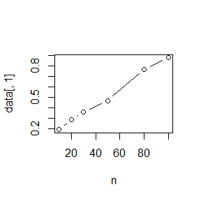

```r
data(data2)
n <- c(10, 20, 30, 50, 80, 100)
plot(n, data[ , 1], type = 'b')
```

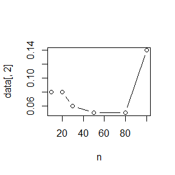

```r
plot(n, data[ , 2], type = 'b')
```

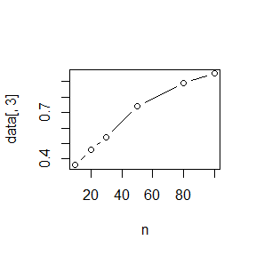

```r
plot(n, data[ , 3], type = 'b')
```

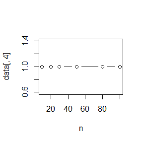

```r
plot(n, data[ , 4], type = 'b')
```

## Homework-2019-11-29

This homework is about MCMC algorithm.

## Question 1

Implement a random walk Metropolis sampler for generating the standard Laplace distribution (see Exercise 3.2). For the increment, simulate from a normal distribution. Compare the chains generated when different variances are used for the proposal distribution, Also, compute the acceptance rates of each chain.

## Answer 1

```r
# write a funciton of random walk Metropolis sampler
rw.Metropolis <- function(sigma, x0, N) {
  x <- numeric(N)
  x[1] <- x0
  u <- runif(N)
  k <- 0
  for (i in 2:N) {
    y <- rnorm(1, x[i-1], sigma)
    if (u[i] <= exp(-((abs(y)) - (abs(x[i-1])))))
      x[i] <- y
    else {
      x[i] <- x[i-1]
      k <- k+1
    }
  }
  return(list(x = x, k = k))
}

N <- 2000
sigma <- c(.05, .5, 2, 16)
set.seed(1234)

# apply to different variances
x0 <- 25
rw1 <- rw.Metropolis(sigma[1], x0, N)
rw2 <- rw.Metropolis(sigma[2], x0, N)
rw3 <- rw.Metropolis(sigma[3], x0, N)
rw4 <- rw.Metropolis(sigma[4], x0, N)
rw <- cbind(rw1$x, rw2$x, rw3$x, rw4$x)

print(c(rw1$k, rw2$k, rw3$k, rw4$k))
```

```
## [1]   43  325  929 1789
```

```r
# compute the acceptance rates of different varainces
print(c(1-rw1$k/N,1-rw2$k/N,1-rw3$k/N,1-rw4$k/N))
```

```
## [1] 0.9785 0.8375 0.5355 0.1055
```

The acceptance rates of each chain are 0.9785, 0.8375, 0.5355, and 0.1055, respectively. The second and third chains have the nice acceptance rates. We can see this by comparing quantiles with the ture distribution in the following:

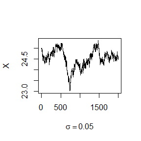

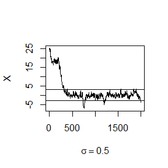

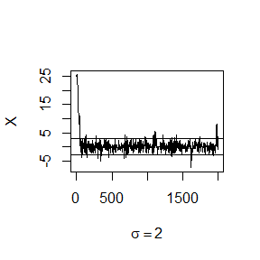

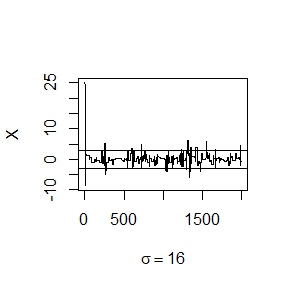

```r
#par(mfcol = c(2, 2)) # display 4 graphs together
refline <- c(log(2 * .025), -log(2 * (1 - .975)))
for (j in 1:4) {
  plot(rw[, j], type = 'l', xlab = bquote(sigma == .(round(sigma[j], 3))), ylab = 'X', ylim = range(rw[, j]))
  abline(h = refline)
}
```

```r
#par(mfcol = c(1, 1)) # reset to default

a <- c(.05, seq(.1, .9, .1), .95)
# compute true quantiles of standard Laplace distribution
Q1 <- log(2 * a[1:5])
Q2 <- -log(2 * (1 - a[6:11]))
Q <- c(Q1, Q2)

mc <- rw[501:N, ]
Qrw <- apply(mc, 2, function(x) quantile(x, a))
knitr::kable(round(cbind(Q, Qrw), 3), col.names = c('TRUE', 'rw1', 'rw2', 'rw3', 'rw4'))
```

|  | TRUE | rw1 | rw2 | rw3 | rw4 |
| --- | --- | --- | --- | --- | --- |
| 5% | -2.303 | 23.668 | -2.913 | -2.084 | -1.802 |
| 10% | -1.609 | 23.886 | -1.807 | -1.447 | -1.214 |
| 20% | -0.916 | 24.122 | -1.070 | -0.851 | -0.713 |
| 30% | -0.511 | 24.284 | -0.669 | -0.446 | -0.509 |
| 40% | -0.223 | 24.395 | -0.332 | -0.162 | -0.165 |
| 50% | 0.000 | 24.477 | -0.117 | -0.006 | 0.118 |
| 60% | 0.223 | 24.572 | 0.071 | 0.226 | 0.205 |
| 70% | 0.511 | 24.658 | 0.386 | 0.561 | 0.514 |
| 80% | 0.916 | 24.762 | 0.782 | 0.928 | 0.980 |
| 90% | 1.609 | 25.019 | 1.355 | 1.675 | 1.841 |
| 95% | 2.303 | 25.134 | 1.892 | 2.570 | 2.966 |

## Homework-2019-12-06

This homework is about data structure and EM algorithm.

### Question 1

The natural logarithm and exponential functions are inverse of each other, so that mathematically log(exp(x))=exp(log(x))=x. Show by example that this property does not hold exactly in computer arithmetic. Does the identity hold with near equality? (See all.equal.)

### Answer 1

```r
x <- seq(1, 100, .1)
isTRUE(log(exp(x)) == exp(log(x)))
```

```
## [1] FALSE
```

The outcome is ‘FALSE’ and so indicates that the property stated above does not hold exactly in computer arithmetic.

```r
isTRUE(all.equal(log(exp(x)),exp(log(x))))
```

```
## [1] TRUE
```

```r
isTRUE(all.equal(log(exp(x)),x))
```

```
## [1] TRUE
```

```r
isTRUE(all.equal(exp(log(x)),x))
```

```
## [1] TRUE
```

However, the identity holds with near equality, which can be verified using function ‘all.equal’.

### Question 2

Write a function to solve the equation
$$\frac{2 \Gamma\left(\frac{k}{2}\right)}{\sqrt{\pi(k-1)} \Gamma\left(\frac{k-1}{2}\right)} \int_{0}^{c_{k-1}}\left(1+\frac{u^{2}}{k-1}\right)^{-k / 2} d u = \frac{2 \Gamma\left(\frac{k+1}{2}\right)}{\sqrt{\pi k} \Gamma\left(\frac{k}{2}\right)} \int_{0}^{c_{k}}\left(1+\frac{u^{2}}{k}\right)^{-(k+1) / 2} d u$$
for a, where
$$c_{k}=\sqrt{\frac{a^{2} k}{k+1-a^{2}}}$$
Compare the solutions with the points A(k) in Exercise 11.4.

### Answer 2

First we take a look at Exercise 11.4.

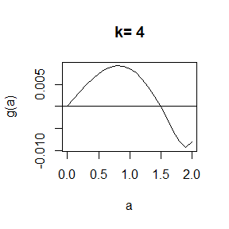

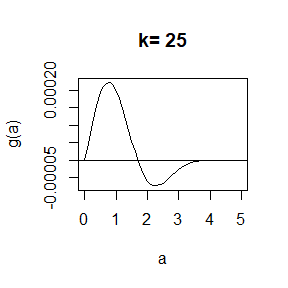

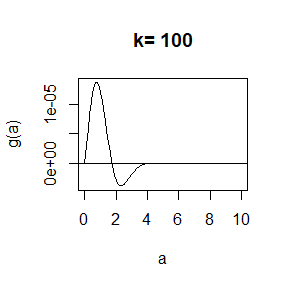

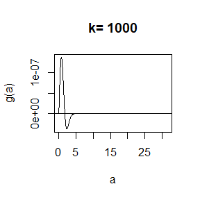

```r
# find the intervals in which the roots fall
f <- function(a, k) 1-pt(sqrt(a^2*k/(k+1-a^2)), k)
k <- c(4, 25, 100, 1000)
#par(mfcol =  c(2, 2))
for (i in k) {
  g <- function(x) f(x, i-1)-f(x, i)
    a <- seq(0, sqrt(i), .1)
  plot(a, g(a), type = 'l', main = paste('k=',i))
  abline(h = 0)
}
```

From the figures plotted when k = 4, 25, 100 and 1000, we can conclude that the roots will fall in the interval (1, 2).

In Exercise 11.4, we can solve the equation when k = 4:25, 100, 500, 1000. The R codes are as follows and the outcomes are listed in a table:

```r
# Exercise 11.4
f <- function(a, k) 1-pt(sqrt(a^2*k/(k+1-a^2)), k)
k <- c(4:25, 100, 500, 1000)
Ak <- numeric(length(k))
i <- 1
for (j in k) {
  g <- function(x) f(x, j-1)-f(x, j)
  Ak[i] <- uniroot(g, lower = 1, upper = 2)$root
  i <- i+1
}
knitr::kable(cbind(k,Ak))
```

| k | Ak |
| --- | --- |
| 4 | 1.492103 |
| 5 | 1.533556 |
| 6 | 1.562744 |
| 7 | 1.584430 |
| 8 | 1.601185 |
| 9 | 1.614521 |
| 10 | 1.625390 |
| 11 | 1.634419 |
| 12 | 1.642038 |
| 13 | 1.648554 |
| 14 | 1.654190 |
| 15 | 1.659114 |
| 16 | 1.663452 |
| 17 | 1.667304 |
| 18 | 1.670745 |
| 19 | 1.673840 |
| 20 | 1.676637 |
| 21 | 1.679178 |
| 22 | 1.681496 |
| 23 | 1.683620 |
| 24 | 1.685572 |
| 25 | 1.687373 |
| 100 | 1.720608 |
| 500 | 1.729756 |
| 1000 | 1.730908 |

Then we turn to Exercise 11.5.

```r
# Exercise 11.5
f <- function(k) 2/sqrt(pi*k)*exp(lgamma((k+1)/2)-lgamma(k/2))
ck <- function(a, k) sqrt(a^2*k/(k+1-a^2))
g <- function(u, k) (1+u^2/k)^(-(k+1)/2)
k <- c(4:25, 100, 500, 1000)
root <- numeric(length(k))
i <- 1
for (j in k) {
  ff <- function(a) f(j)*integrate(function(u) {g(u, j)}, 0, ck(a, j))$value -       f(j-1)*integrate(function(u) {g(u, j-1)}, 0, ck(a, j-1))$value
  root[i] <- uniroot(ff, lower = 1, upper = 2)$root
  i <- i+1
}
knitr::kable(cbind(k, Ak, root))
```

| k | Ak | root |
| --- | --- | --- |
| 4 | 1.492103 | 1.492103 |
| 5 | 1.533556 | 1.533556 |
| 6 | 1.562744 | 1.562744 |
| 7 | 1.584430 | 1.584430 |
| 8 | 1.601185 | 1.601185 |
| 9 | 1.614521 | 1.614521 |
| 10 | 1.625390 | 1.625390 |
| 11 | 1.634419 | 1.634419 |
| 12 | 1.642038 | 1.642038 |
| 13 | 1.648554 | 1.648554 |
| 14 | 1.654190 | 1.654190 |
| 15 | 1.659114 | 1.659114 |
| 16 | 1.663452 | 1.663452 |
| 17 | 1.667304 | 1.667304 |
| 18 | 1.670745 | 1.670745 |
| 19 | 1.673840 | 1.673840 |
| 20 | 1.676637 | 1.676637 |
| 21 | 1.679178 | 1.679178 |
| 22 | 1.681496 | 1.681496 |
| 23 | 1.683620 | 1.683620 |
| 24 | 1.685572 | 1.685572 |
| 25 | 1.687373 | 1.687373 |
| 100 | 1.720608 | 1.720608 |
| 500 | 1.729756 | 1.729756 |
| 1000 | 1.730908 | 1.730907 |

In the above table, the outcomes in ‘Ak’ column are the outcomes in Exercise 11.4 and these in ‘root’ column are the outcomes in Exercise 11.5. We can see that the results are the same. This result is obvious as these two questions are in fact the same.

### Question 3

A-B-O blood type problem

Let the three alleles be A, B, and O with allele frequencies p, q, and r. The 6 genotype frequencies under HWE and complete counts are as follows.

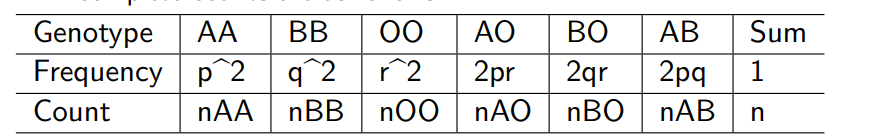

[output not shown]

Observed data: $n_{A\cdot}=n_{AA}+n_{AO}=28$(A-type), $n_{B\cdot}=n_{BB}+n_{BO}=24$(B-type), $n_{OO}=41$(O_type), $n_{AB}=70$(AB-type).  
1. Use EM algorithm to solve MLE of p and q (consider missing data $n_{AA}$ and $n_{BB}$).  
2. Show that the log-maximum likelihood values in M-steps are increasing via line plot.

### Answer 3

```r
nA <- 28
nB <- 24
nOO <- 41
nAB <- 70
# EM algorithm
theta0 <- c(.5, .3)
l <- numeric(1000)
for (j in 1:1000) {
  E <- function(theta) {
    p <- theta[1]
    q <- theta[2]
    r <- 1-p-q
    p0 <- theta0[1]
    q0 <- theta0[2]
    r0 <- 1-p0-q0
    return(2*nA*(log(p)+r0/(p0+2*r0)*log(2*r/p))+2*nB*(log(q)+r0/(q0+2*r0)*log(2*r/q))+2*nOO*log(r)+nAB*log(2*p*q))
  }
  Obj <- function(theta) -E(theta)
  optim <- optim(c(.1, .1), Obj)
  theta0 <- optim$par
  l[j] <- E(theta0)
}
print(theta0)
```

```
## [1] 0.3273325 0.3104528
```

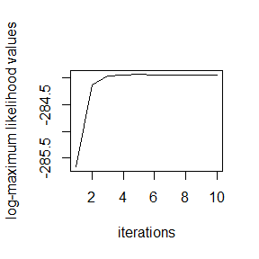

```r
plot(l[1:10], type = 'l', xlab = 'iterations', ylab = 'log-maximum likelihood values')
```

According to EM algorithm, we obtain the MLE of p and q are 0.3273325 and 0.3104528 respectively.  
From the line plot of log-maximum likelihood values of 10 iterations, we can see that the values are increasing and converge quickly.

## Homework-2019-12-13

This homework is about functional programming.

### Question 1

Use both for loops and lappy() to fit linear models to the $mtcars$ using the formulas stored in this list:

```r
formulas <- list(
  mpg ~ disp,
  mpg ~ I(1 / disp),
  mpg ~ disp + wt,
  mpg ~ I(1 / disp) + wt
)
```

### Answer 1

```r
attach(mtcars)
# with lapply
lapply(formulas, lm)
```

```
## [[1]]
##
## Call:
## FUN(formula = X[[i]])
##
## Coefficients:
## (Intercept)         disp
##    29.59985     -0.04122
##
##
## [[2]]
##
## Call:
## FUN(formula = X[[i]])
##
## Coefficients:
## (Intercept)    I(1/disp)
##       10.75      1557.67
##
##
## [[3]]
##
## Call:
## FUN(formula = X[[i]])
##
## Coefficients:
## (Intercept)         disp           wt
##    34.96055     -0.01772     -3.35083
##
##
## [[4]]
##
## Call:
## FUN(formula = X[[i]])
##
## Coefficients:
## (Intercept)    I(1/disp)           wt
##      19.024     1142.560       -1.798
```

```r
# for loop
out1 <- vector('list', length(formulas))
for (i in 1:length(formulas)) {
  out1[[i]] <- lm(formulas[[i]])
}
out1
```

```
## [[1]]
##
## Call:
## lm(formula = formulas[[i]])
##
## Coefficients:
## (Intercept)         disp
##    29.59985     -0.04122
##
##
## [[2]]
##
## Call:
## lm(formula = formulas[[i]])
##
## Coefficients:
## (Intercept)    I(1/disp)
##       10.75      1557.67
##
##
## [[3]]
##
## Call:
## lm(formula = formulas[[i]])
##
## Coefficients:
## (Intercept)         disp           wt
##    34.96055     -0.01772     -3.35083
##
##
## [[4]]
##
## Call:
## lm(formula = formulas[[i]])
##
## Coefficients:
## (Intercept)    I(1/disp)           wt
##      19.024     1142.560       -1.798
```

### Question 2

Fit the model $mpg$ ~ $disp$ to each of the bootstrap replicates of $mtcars$ in the list below by using for loop and lappy(). Can you do it without any anonymous function?

```r
set.seed(1234)
bootstrap <- lapply(1:10, function(i) {
  rows <- sample(1:nrow(mtcars), rep = TRUE)
  mtcars[rows, ]
})
```

### Answer 2

```r
# with lapply
lapply(bootstrap, function(x) lm(mpg ~ disp, data = x))
```

```
## [[1]]
##
## Call:
## lm(formula = mpg ~ disp, data = x)
##
## Coefficients:
## (Intercept)         disp
##     30.5373      -0.0444
##
##
## [[2]]
##
## Call:
## lm(formula = mpg ~ disp, data = x)
##
## Coefficients:
## (Intercept)         disp
##    29.22675     -0.04133
##
##
## [[3]]
##
## Call:
## lm(formula = mpg ~ disp, data = x)
##
## Coefficients:
## (Intercept)         disp
##    27.82696     -0.03348
##
##
## [[4]]
##
## Call:
## lm(formula = mpg ~ disp, data = x)
##
## Coefficients:
## (Intercept)         disp
##    32.01974     -0.05052
##
##
```

[output cut: 43 more lines]

```
## lm(formula = mpg ~ disp, data = x)
##
## Coefficients:
## (Intercept)         disp
##    30.46265     -0.04743
##
##
## [[10]]
##
## Call:
## lm(formula = mpg ~ disp, data = x)
##
## Coefficients:
## (Intercept)         disp
##    28.04377     -0.03652
```

```r
# for loop
out2 <- vector('list', length(bootstrap))
for (i in 1:length(bootstrap)) {
  out2[[i]] <- lm(mpg ~ disp, data = bootstrap[[i]])
}
out2
```

```
## [[1]]
##
## Call:
## lm(formula = mpg ~ disp, data = bootstrap[[i]])
##
## Coefficients:
## (Intercept)         disp
##     30.5373      -0.0444
##
##
## [[2]]
##
## Call:
## lm(formula = mpg ~ disp, data = bootstrap[[i]])
##
## Coefficients:
## (Intercept)         disp
##    29.22675     -0.04133
##
##
## [[3]]
##
## Call:
## lm(formula = mpg ~ disp, data = bootstrap[[i]])
##
## Coefficients:
## (Intercept)         disp
##    27.82696     -0.03348
##
##
## [[4]]
##
## Call:
## lm(formula = mpg ~ disp, data = bootstrap[[i]])
##
## Coefficients:
## (Intercept)         disp
##    32.01974     -0.05052
##
##
```

[output cut: 43 more lines]

```
## lm(formula = mpg ~ disp, data = bootstrap[[i]])
##
## Coefficients:
## (Intercept)         disp
##    30.46265     -0.04743
##
##
## [[10]]
##
## Call:
## lm(formula = mpg ~ disp, data = bootstrap[[i]])
##
## Coefficients:
## (Intercept)         disp
##    28.04377     -0.03652
```

```r
# lapply without anonymous function
lapply(bootstrap, lm, formula = mpg ~ disp)
```

```
## [[1]]
##
## Call:
## FUN(formula = ..1, data = X[[i]])
##
## Coefficients:
## (Intercept)         disp
##     30.5373      -0.0444
##
##
## [[2]]
##
## Call:
## FUN(formula = ..1, data = X[[i]])
##
## Coefficients:
## (Intercept)         disp
##    29.22675     -0.04133
##
##
## [[3]]
##
## Call:
## FUN(formula = ..1, data = X[[i]])
##
## Coefficients:
## (Intercept)         disp
##    27.82696     -0.03348
##
##
## [[4]]
##
## Call:
## FUN(formula = ..1, data = X[[i]])
##
## Coefficients:
## (Intercept)         disp
##    32.01974     -0.05052
##
##
```

[output cut: 43 more lines]

```
## FUN(formula = ..1, data = X[[i]])
##
## Coefficients:
## (Intercept)         disp
##    30.46265     -0.04743
##
##
## [[10]]
##
## Call:
## FUN(formula = ..1, data = X[[i]])
##
## Coefficients:
## (Intercept)         disp
##    28.04377     -0.03652
```

### Question 3

For each model in the previous two exercises, extract $R^2$ using the function below.

```r
rsq <- function(mod) summary(mod)$r.squared
```

### Answer 3

```r
lapply(out1, rsq)
```

```
## [[1]]
## [1] 0.7183433
##
## [[2]]
## [1] 0.8596865
##
## [[3]]
## [1] 0.7809306
##
## [[4]]
## [1] 0.8838038
```

```r
lapply(out2, rsq)
```

```
## [[1]]
## [1] 0.7817567
##
## [[2]]
## [1] 0.7813869
##
## [[3]]
## [1] 0.7191574
##
## [[4]]
## [1] 0.7880896
##
## [[5]]
## [1] 0.6350857
##
## [[6]]
## [1] 0.8092306
##
## [[7]]
## [1] 0.7153903
##
## [[8]]
## [1] 0.7117518
##
## [[9]]
## [1] 0.6652465
##
## [[10]]
## [1] 0.5906548
```

### Question 4

The following code simulates the performance of a t-test for non-normal data. Using $sapply()$ and an anonymous function to extract the p-values from every trial.

```r
set.seed(1234)
trials <- replicate(
  100,
  t.test(rpois(10, 10), rpois(7, 10)),
  simplify = FALSE
)
```

Extra challenge: get rid of the anonymous function by using [[ directly.

### Answer 4

```r
# with sapply
sapply(trials, function(x) x$p.value)
```

```
##   [1] 0.92573839 0.38341791 0.21070462 0.41458918 0.26121206 0.72223937
##   [7] 0.29887169 0.95162894 0.26398664 0.62018151 0.51388383 0.94676108
##  [13] 0.05206634 0.94395869 0.90872276 0.91948631 0.66419598 0.29837025
##  [19] 0.29940554 0.83506207 0.45274078 0.90320828 0.79263778 0.45399170
##  [25] 0.38923722 0.69542630 0.26739653 0.38567329 0.31137487 0.36010634
##  [31] 0.39754771 0.72253407 0.42186171 0.12771643 0.23170443 0.68265125
##  [37] 0.71252902 0.12724649 0.75353630 0.94884686 0.87276882 0.41388298
##  [43] 0.25224053 0.84404036 0.16580146 0.42473329 0.82280924 0.71272703
##  [49] 0.30947058 0.92816784 0.27134690 0.62008647 0.49758173 0.02775463
##  [55] 0.78775614 0.26248714 0.77273771 0.68416168 0.08687832 0.04574362
##  [61] 0.44178950 0.36827740 0.64265435 0.47847663 0.10832740 0.75695184
##  [67] 0.61642417 0.01474650 0.18023871 0.42316145 0.38702375 0.27030894
##  [73] 0.92266032 0.75504614 0.65781938 0.34910615 0.22083614 0.53165720
##  [79] 0.14727409 0.50490437 0.42920650 0.71256710 0.72931439 0.90676814
##  [85] 0.85988192 0.87366680 0.91047506 0.99255659 0.15198012 0.09537499
##  [91] 0.37213020 0.96151424 0.97595090 0.30669922 0.42738809 0.75571001
##  [97] 0.15155800 0.06214524 0.29324608 0.83599679
```

```r
# using [[
sapply(trials, '[[', 'p.value')
```

```
##   [1] 0.92573839 0.38341791 0.21070462 0.41458918 0.26121206 0.72223937
##   [7] 0.29887169 0.95162894 0.26398664 0.62018151 0.51388383 0.94676108
##  [13] 0.05206634 0.94395869 0.90872276 0.91948631 0.66419598 0.29837025
##  [19] 0.29940554 0.83506207 0.45274078 0.90320828 0.79263778 0.45399170
##  [25] 0.38923722 0.69542630 0.26739653 0.38567329 0.31137487 0.36010634
##  [31] 0.39754771 0.72253407 0.42186171 0.12771643 0.23170443 0.68265125
##  [37] 0.71252902 0.12724649 0.75353630 0.94884686 0.87276882 0.41388298
##  [43] 0.25224053 0.84404036 0.16580146 0.42473329 0.82280924 0.71272703
##  [49] 0.30947058 0.92816784 0.27134690 0.62008647 0.49758173 0.02775463
##  [55] 0.78775614 0.26248714 0.77273771 0.68416168 0.08687832 0.04574362
##  [61] 0.44178950 0.36827740 0.64265435 0.47847663 0.10832740 0.75695184
##  [67] 0.61642417 0.01474650 0.18023871 0.42316145 0.38702375 0.27030894
##  [73] 0.92266032 0.75504614 0.65781938 0.34910615 0.22083614 0.53165720
##  [79] 0.14727409 0.50490437 0.42920650 0.71256710 0.72931439 0.90676814
##  [85] 0.85988192 0.87366680 0.91047506 0.99255659 0.15198012 0.09537499
##  [91] 0.37213020 0.96151424 0.97595090 0.30669922 0.42738809 0.75571001
##  [97] 0.15155800 0.06214524 0.29324608 0.83599679
```

### Question 5

Implement $mcsapply()$, a multicore version of $sapply()$. Can you implement $mcvapply()$, a parallel version of $vapply()$? Why or why not?

### Answer 5

$mcsapply()$ is just ‘unlist($*$)’, where $*$ is the outcome of $mclapply()$. We implement it as follows.

```r
# mcsapply()
library(parallel)
boot_df <- function(x) x[sample(nrow(x), rep = T), ]
rsquared <- function(mod) summary(mod)$r.squared
boot_lm <- function(i) {
  rsquared(lm(mpg ~ wt + disp, data = boot_df(mtcars)))
}
system.time(sapply(1:1e5, boot_lm))
system.time(unlist(mclapply(1:1e5, boot_lm, mc.cores = 4)))
```

In Windows, $mclapply()$ fails and we run the R codes on Linux. The outcomes are in the following picture.

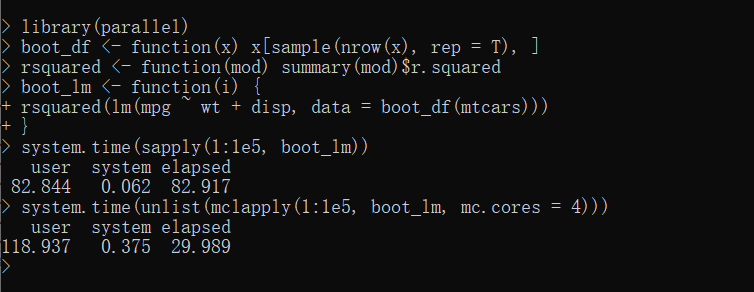

However, a parallel version of $vapply()$ can not be implemented because data structure is considered and we should not diapatch the tasks to different cores easily.